| title: “Palmer Penguins Structural and Morphological Analysis” |
| --- |
| author: “Elaina Reynolds” |
| date: “2026-08-02” |
| output: html_document |

# Introduction

The `palmerpenguins` dataset contains size measurements, species classifications, and island observations for adult penguins collected near Palmer Station, Antarctica. The data were collected by Dr. Kristen Gorman and the Palmer Station Long Term Ecological Research (LTER) Program.

This dataset includes measurements for three penguin species—**Adélie** (*Pygoscelis adeliae*), **Chinstrap** (*Pygoscelis antarcticus*), and **Gentoo** (*Pygoscelis papua*)—across three islands in the Palmer Archipelago: Biscoe, Dream, and Torgersen.

In this analysis, we aim to explore: 1. Sexual dimorphism and which morphological traits best distinguish male and female penguins. 2. Interspecific physical variations across species (e.g., bill length, bill depth, flipper length, and body mass). 3. The spatial distribution and species composition across the different Antarctic island sites.

# Part B: Exploratory Data Analysis

### Dataset Dimensions

To understand the overall size of our dataset, we check the number of columns (variables) and rows (individual penguins).

```r
# Calculate number of columns (variables)
num_cols <- ncol(penguins)

# Calculate number of rows (individual penguin entries)
num_rows <- nrow(penguins)

num_cols
```

```
## [1] 8
```

```r
num_rows
```

```
## [1] 344
```

- **Columns:** The dataset contains **8** variables.
- **Penguin count:** We have data recorded for **344** individual penguins.

### Sex Distribution & Subsetting

Next, we evaluate whether male and female penguins are represented equally in the dataset.

> **Note on `grep()` vs Exact Matching:** When subsetting by sex, exact equality (`sex == "female"`) or exact string matching is safer than standard pattern matching like `grep("female", ...)` because the substring `"female"` contains `"male"`, which can lead to accidental misclassification or double-counting if regex boundaries aren’t strictly defined.

```r
# Summary table of sex counts
table(penguins$sex, useNA = "ifany")
```

```
##
## female   male   <NA>
##    165    168     11
```

```r
# Filter into distinct dataframes using exact matching
pmale <- penguins %>% filter(sex == "male")
pfemale <- penguins %>% filter(sex == "female")

# Check row counts for subsetted dataframes
nrow(pmale)
```

```
## [1] 168
```

```r
nrow(pfemale)
```

```
## [1] 165
```

- **Observation:** The dataset contains **168 males** and **165 females** (along with 11 `NA` values where sex was not recorded). Representation between males and females is nearly equal.

### Species Representation & Subsetting

Now, we check if each of the three species is represented equally.

```r
# Summary table of species counts
table(penguins$species)
```

```
##
##    Adelie Chinstrap    Gentoo
##       152        68       124
```

```r
# Filter into species-specific dataframes
pAdel <- penguins %>% filter(species == "Adelie")
pChin <- penguins %>% filter(species == "Chinstrap")
pGen  <- penguins %>% filter(species == "Gentoo")

# Verify sizes of each subset
nrow(pAdel)
```

```
## [1] 152
```

```r
nrow(pChin)
```

```
## [1] 68
```

```r
nrow(pGen)
```

```
## [1] 124
```

- **Observation:** Species representation is **not equal**. **Adélie** is the most abundant (`152`), followed by **Gentoo** (`124`), while **Chinstrap** has significantly fewer individuals represented (`68`).

### Island Representation & Subsetting

Finally, we assess the representation of penguins across the three islands.

```r
# Summary table of island counts
table(penguins$island)
```

```
##
##    Biscoe     Dream Torgersen
##       168       124        52
```

```r
# Filter into island-specific dataframes
iBis   <- penguins %>% filter(island == "Biscoe")
iDream <- penguins %>% filter(island == "Dream")
iTorg  <- penguins %>% filter(island == "Torgersen")

# Verify sizes of each island subset
nrow(iBis)
```

```
## [1] 168
```

```r
nrow(iDream)
```

```
## [1] 124
```

```r
nrow(iTorg)
```

```
## [1] 52
```

- **Observation:** Island representation is also **unequal**. **Biscoe Island** has the largest sample size (`168`), followed by **Dream Island** (`124`), and **Torgersen Island** has the smallest sample size (`52`).

# Part C: Data Visualization

To inspect morphological differences and geographic distribution, we construct three customized plots using `ggplot2`.

### 1. Sexual Dimorphism: What measures best distinguish males from females?

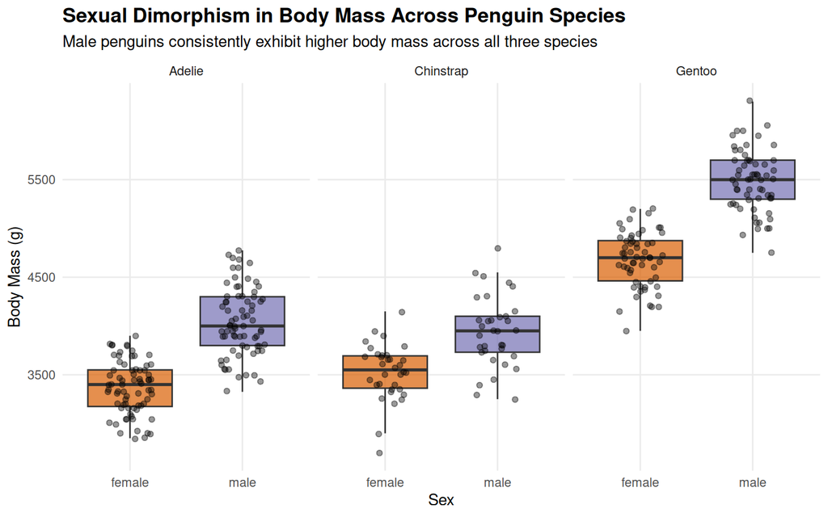

```r
# Boxplot comparing body mass across sex and species with custom styling
ggplot(drop_na(penguins, sex), aes(x = sex, y = body_mass_g, fill = sex)) +
  geom_boxplot(alpha = 0.7, outlier.shape = NA) +
  geom_jitter(position = position_jitter(0.2), alpha = 0.4, size = 1.5) +
  facet_wrap(~species) +
  scale_fill_manual(values = c("female" = "#d95f02", "male" = "#7570b3")) +
  theme_minimal() +
  labs(
    title = "Sexual Dimorphism in Body Mass Across Penguin Species",
    subtitle = "Male penguins consistently exhibit higher body mass across all three species",
    x = "Sex",
    y = "Body Mass (g)",
    fill = "Sex"
  ) +
  theme(
    plot.title = element_text(face = "bold", size = 14),
    legend.position = "none",
    panel.grid.minor = element_blank()
  )
```

### 2. Species Differentiation: What measures best distinguish species?

We plot **Bill Length (mm)** versus **Bill Depth (mm)** in a scatterplot to see how species separate in morphological space.

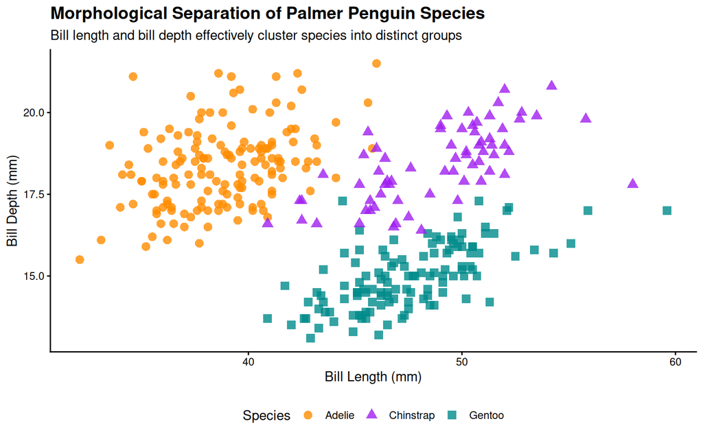

```r
# Scatterplot comparing bill length vs bill depth by species
ggplot(drop_na(penguins, species), aes(x = bill_length_mm, y = bill_depth_mm, color = species, shape = species)) +
  geom_point(size = 3, alpha = 0.8) +
  scale_color_manual(values = c("Adelie" = "darkorange", "Chinstrap" = "purple", "Gentoo" = "cyan4")) +
  theme_classic() +
  labs(
    title = "Morphological Separation of Palmer Penguin Species",
    subtitle = "Bill length and bill depth effectively cluster species into distinct groups",
    x = "Bill Length (mm)",
    y = "Bill Depth (mm)",
    color = "Species",
    shape = "Species"
  ) +
  theme(
    plot.title = element_text(face = "bold", size = 14),
    legend.position = "bottom"
  )
```

- **Key Takeaway:** Bill geometry cleanly separates species:
  - **Gentoo** penguins have long, shallow bills (high length, low depth).
  - **Adélie** penguins have short, deep bills (low length, high depth).
  - **Chinstrap** penguins have long, deep bills (high length, high depth).

### 3. Spatial Distribution: Which species inhabit which islands?

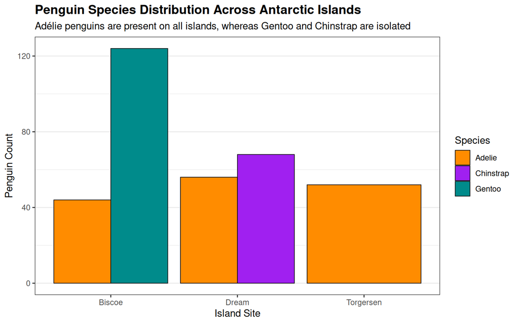

```r
# Stacked bar plot showing species distribution across islands
ggplot(penguins, aes(x = island, fill = species)) +
  geom_bar(position = "dodge", color = "black", linewidth = 0.3) +
  scale_fill_manual(values = c("Adelie" = "darkorange", "Chinstrap" = "purple", "Gentoo" = "cyan4")) +
  theme_bw() +
  labs(
    title = "Penguin Species Distribution Across Antarctic Islands",
    subtitle = "Adélie penguins are present on all islands, whereas Gentoo and Chinstrap are isolated",
    x = "Island Site",
    y = "Penguin Count",
    fill = "Species"
  ) +
  theme(
    plot.title = element_text(face = "bold", size = 14),
    panel.grid.major.x = element_blank()
  )
```

- **Key Takeaway:**
  - **Torgersen Island** is inhabited *only* by **Adélie** penguins.
  - **Dream Island** hosts **Adélie** and **Chinstrap** penguins.
  - **Biscoe Island** hosts **Adélie** and **Gentoo** penguins.
  - **Adélie** is the only generalist species present on all three islands.```